# Risk Factor Analysis

## Outcome Variable

**Outcome Variable:** stunted

## Predictor Variables

**Intervention Variable:** tr

**Adjustment Set:**

unadjusted

## Stratifying Variables

The analysis was stratified on these variable(s):

- enstunt
- agecat
- studyid
- country

## Data Summary

| enstunt | agecat | studyid | country | tr | stunted | n_cell | n |
| --- | --- | --- | --- | --- | --- | --- | --- |
| 0 | 24 months | ki1000107-Serrinha-VitA | BRAZIL | Control | 0 | 40 | 95 |
| 0 | 24 months | ki1000107-Serrinha-VitA | BRAZIL | Control | 1 | 12 | 95 |
| 0 | 24 months | ki1000107-Serrinha-VitA | BRAZIL | VitA | 0 | 34 | 95 |
| 0 | 24 months | ki1000107-Serrinha-VitA | BRAZIL | VitA | 1 | 9 | 95 |
| 1 | 6 months | ki1000107-Serrinha-VitA | BRAZIL | Control | 1 | 6 | 9 |
| 1 | 6 months | ki1000107-Serrinha-VitA | BRAZIL | VitA | 1 | 3 | 9 |
| 0 | 6 months | ki1000107-Serrinha-VitA | BRAZIL | Control | 0 | 10 | 26 |
| 0 | 6 months | ki1000107-Serrinha-VitA | BRAZIL | VitA | 0 | 16 | 26 |
| 1 | 24 months | ki1000107-Serrinha-VitA | BRAZIL | Control | 1 | 19 | 36 |
| 1 | 24 months | ki1000107-Serrinha-VitA | BRAZIL | VitA | 1 | 17 | 36 |
| 0 | 24 months | ki1000110-WASH-Bangladesh | BANGLADESH | Control | 0 | 139 | 843 |
| 0 | 24 months | ki1000110-WASH-Bangladesh | BANGLADESH | Control | 1 | 52 | 843 |
| 0 | 24 months | ki1000110-WASH-Bangladesh | BANGLADESH | LNS | 0 | 181 | 843 |
| 0 | 24 months | ki1000110-WASH-Bangladesh | BANGLADESH | LNS | 1 | 41 | 843 |
| 0 | 24 months | ki1000110-WASH-Bangladesh | BANGLADESH | Other | 0 | 323 | 843 |
| 0 | 24 months | ki1000110-WASH-Bangladesh | BANGLADESH | Other | 1 | 107 | 843 |
| 1 | 24 months | ki1000110-WASH-Bangladesh | BANGLADESH | Control | 0 | 9 | 287 |
| 1 | 24 months | ki1000110-WASH-Bangladesh | BANGLADESH | Control | 1 | 55 | 287 |
| 1 | 24 months | ki1000110-WASH-Bangladesh | BANGLADESH | LNS | 0 | 4 | 287 |
| 1 | 24 months | ki1000110-WASH-Bangladesh | BANGLADESH | LNS | 1 | 71 | 287 |
| 1 | 24 months | ki1000110-WASH-Bangladesh | BANGLADESH | Other | 0 | 14 | 287 |
| 1 | 24 months | ki1000110-WASH-Bangladesh | BANGLADESH | Other | 1 | 134 | 287 |
| 0 | 6 months | ki1000110-WASH-Bangladesh | BANGLADESH | Control | 0 | 126 | 566 |
| 0 | 6 months | ki1000110-WASH-Bangladesh | BANGLADESH | LNS | 0 | 156 | 566 |
| 0 | 6 months | ki1000110-WASH-Bangladesh | BANGLADESH | Other | 0 | 284 | 566 |
| 1 | 6 months | ki1000110-WASH-Bangladesh | BANGLADESH | Control | 1 | 29 | 99 |
| 1 | 6 months | ki1000110-WASH-Bangladesh | BANGLADESH | LNS | 1 | 29 | 99 |
| 1 | 6 months | ki1000110-WASH-Bangladesh | BANGLADESH | Other | 1 | 41 | 99 |
| 1 | 24 months | ki1000111-WASH-Kenya | KENYA | Control | 0 | 18 | 452 |
| 1 | 24 months | ki1000111-WASH-Kenya | KENYA | Control | 1 | 134 | 452 |

[output cut: 259 more lines]

The following strata were considered:

- enstunt: 0, agecat: 24 months, studyid: iLiNS_DYADM_LNS, country: MALAWI
- enstunt: 0, agecat: 24 months, studyid: ki1000107-Serrinha-VitA, country: BRAZIL
- enstunt: 0, agecat: 24 months, studyid: ki1000110-WASH-Bangladesh, country: BANGLADESH
- enstunt: 0, agecat: 24 months, studyid: ki1000111-WASH-Kenya, country: KENYA
- enstunt: 0, agecat: 24 months, studyid: ki1000125-AgaKhanUniv, country: PAKISTAN
- enstunt: 0, agecat: 24 months, studyid: ki1000304-Vitamin-B12, country: INDIA
- enstunt: 0, agecat: 24 months, studyid: ki1000304-ZnMort, country: INDIA
- enstunt: 0, agecat: 24 months, studyid: ki1112895-Burkina Faso Zn, country: BURKINA FASO
- enstunt: 0, agecat: 24 months, studyid: ki1119695-PROBIT, country: BELARUS
- enstunt: 0, agecat: 24 months, studyid: ki1126311-ZVITAMBO, country: ZIMBABWE
- enstunt: 0, agecat: 24 months, studyid: ki1135781-COHORTS, country: GUATEMALA
- enstunt: 0, agecat: 24 months, studyid: ki1148112-iLiNS-DOSE, country: MALAWI
- enstunt: 0, agecat: 24 months, studyid: ki1148112-iLiNS-DYAD-M, country: MALAWI
- enstunt: 0, agecat: 24 months, studyid: ki1148112-LCNI-5, country: MALAWI
- enstunt: 0, agecat: 24 months, studyid: kiGH5241-JiVitA-3, country: BANGLADESH
- enstunt: 0, agecat: 24 months, studyid: kiGH5241-JiVitA-4, country: BANGLADESH
- enstunt: 0, agecat: 6 months, studyid: iLiNS_DYADM_LNS, country: MALAWI
- enstunt: 0, agecat: 6 months, studyid: ki1000107-Serrinha-VitA, country: BRAZIL
- enstunt: 0, agecat: 6 months, studyid: ki1000110-WASH-Bangladesh, country: BANGLADESH
- enstunt: 0, agecat: 6 months, studyid: ki1000111-WASH-Kenya, country: KENYA
- enstunt: 0, agecat: 6 months, studyid: ki1000125-AgaKhanUniv, country: PAKISTAN
- enstunt: 0, agecat: 6 months, studyid: ki1000304-EU, country: INDIA
- enstunt: 0, agecat: 6 months, studyid: ki1000304-Vitamin-B12, country: INDIA
- enstunt: 0, agecat: 6 months, studyid: ki1000304-ZnMort, country: INDIA
- enstunt: 0, agecat: 6 months, studyid: ki1000304b-SAS-CompFeed, country: INDIA
- enstunt: 0, agecat: 6 months, studyid: ki1000304b-SAS-FoodSuppl, country: INDIA
- enstunt: 0, agecat: 6 months, studyid: ki1066203-TanzaniaChild2, country: TANZANIA, UNITED REPUBLIC OF
- enstunt: 0, agecat: 6 months, studyid: ki1112895-Burkina Faso Zn, country: BURKINA FASO
- enstunt: 0, agecat: 6 months, studyid: ki1112895-Guatemala BSC, country: GUATEMALA
- enstunt: 0, agecat: 6 months, studyid: ki1119695-PROBIT, country: BELARUS
- enstunt: 0, agecat: 6 months, studyid: ki1126311-ZVITAMBO, country: ZIMBABWE
- enstunt: 0, agecat: 6 months, studyid: ki1135781-COHORTS, country: GUATEMALA
- enstunt: 0, agecat: 6 months, studyid: ki1148112-iLiNS-DOSE, country: MALAWI
- enstunt: 0, agecat: 6 months, studyid: ki1148112-iLiNS-DYAD-M, country: MALAWI
- enstunt: 0, agecat: 6 months, studyid: ki1148112-LCNI-5, country: MALAWI
- enstunt: 0, agecat: 6 months, studyid: kiGH5241-JiVitA-3, country: BANGLADESH
- enstunt: 0, agecat: 6 months, studyid: kiGH5241-JiVitA-4, country: BANGLADESH
- enstunt: 0, agecat: Birth, studyid: ki1000125-AgaKhanUniv, country: PAKISTAN
- enstunt: 0, agecat: Birth, studyid: ki1000304b-SAS-CompFeed, country: INDIA
- enstunt: 0, agecat: Birth, studyid: ki1119695-PROBIT, country: BELARUS
- enstunt: 0, agecat: Birth, studyid: ki1126311-ZVITAMBO, country: ZIMBABWE
- enstunt: 0, agecat: Birth, studyid: ki1135781-COHORTS, country: GUATEMALA
- enstunt: 0, agecat: Birth, studyid: kiGH5241-JiVitA-3, country: BANGLADESH
- enstunt: 0, agecat: Birth, studyid: kiGH5241-JiVitA-4, country: BANGLADESH
- enstunt: 1, agecat: 24 months, studyid: ki1000107-Serrinha-VitA, country: BRAZIL
- enstunt: 1, agecat: 24 months, studyid: ki1000110-WASH-Bangladesh, country: BANGLADESH
- enstunt: 1, agecat: 24 months, studyid: ki1000111-WASH-Kenya, country: KENYA
- enstunt: 1, agecat: 24 months, studyid: ki1000125-AgaKhanUniv, country: PAKISTAN
- enstunt: 1, agecat: 24 months, studyid: ki1000304-Vitamin-B12, country: INDIA
- enstunt: 1, agecat: 24 months, studyid: ki1000304-ZnMort, country: INDIA
- enstunt: 1, agecat: 24 months, studyid: ki1112895-Burkina Faso Zn, country: BURKINA FASO
- enstunt: 1, agecat: 24 months, studyid: ki1119695-PROBIT, country: BELARUS
- enstunt: 1, agecat: 24 months, studyid: ki1126311-ZVITAMBO, country: ZIMBABWE
- enstunt: 1, agecat: 24 months, studyid: ki1135781-COHORTS, country: GUATEMALA
- enstunt: 1, agecat: 24 months, studyid: ki1148112-iLiNS-DOSE, country: MALAWI
- enstunt: 1, agecat: 24 months, studyid: ki1148112-LCNI-5, country: MALAWI
- enstunt: 1, agecat: 24 months, studyid: kiGH5241-JiVitA-3, country: BANGLADESH
- enstunt: 1, agecat: 24 months, studyid: kiGH5241-JiVitA-4, country: BANGLADESH
- enstunt: 1, agecat: 6 months, studyid: iLiNS_DYADM_LNS, country: MALAWI
- enstunt: 1, agecat: 6 months, studyid: ki1000107-Serrinha-VitA, country: BRAZIL
- enstunt: 1, agecat: 6 months, studyid: ki1000110-WASH-Bangladesh, country: BANGLADESH
- enstunt: 1, agecat: 6 months, studyid: ki1000111-WASH-Kenya, country: KENYA
- enstunt: 1, agecat: 6 months, studyid: ki1000125-AgaKhanUniv, country: PAKISTAN
- enstunt: 1, agecat: 6 months, studyid: ki1000304-EU, country: INDIA
- enstunt: 1, agecat: 6 months, studyid: ki1000304-Vitamin-B12, country: INDIA
- enstunt: 1, agecat: 6 months, studyid: ki1000304-ZnMort, country: INDIA
- enstunt: 1, agecat: 6 months, studyid: ki1000304b-SAS-CompFeed, country: INDIA
- enstunt: 1, agecat: 6 months, studyid: ki1000304b-SAS-FoodSuppl, country: INDIA
- enstunt: 1, agecat: 6 months, studyid: ki1112895-Burkina Faso Zn, country: BURKINA FASO
- enstunt: 1, agecat: 6 months, studyid: ki1112895-Guatemala BSC, country: GUATEMALA
- enstunt: 1, agecat: 6 months, studyid: ki1119695-PROBIT, country: BELARUS
- enstunt: 1, agecat: 6 months, studyid: ki1126311-ZVITAMBO, country: ZIMBABWE
- enstunt: 1, agecat: 6 months, studyid: ki1135781-COHORTS, country: GUATEMALA
- enstunt: 1, agecat: 6 months, studyid: ki1148112-iLiNS-DOSE, country: MALAWI
- enstunt: 1, agecat: 6 months, studyid: ki1148112-iLiNS-DYAD-M, country: MALAWI
- enstunt: 1, agecat: 6 months, studyid: ki1148112-LCNI-5, country: MALAWI
- enstunt: 1, agecat: 6 months, studyid: kiGH5241-JiVitA-3, country: BANGLADESH
- enstunt: 1, agecat: 6 months, studyid: kiGH5241-JiVitA-4, country: BANGLADESH
- enstunt: 1, agecat: Birth, studyid: iLiNS_DYADM_LNS, country: MALAWI
- enstunt: 1, agecat: Birth, studyid: ki1000304b-SAS-CompFeed, country: INDIA
- enstunt: 1, agecat: Birth, studyid: ki1119695-PROBIT, country: BELARUS
- enstunt: 1, agecat: Birth, studyid: ki1126311-ZVITAMBO, country: ZIMBABWE
- enstunt: 1, agecat: Birth, studyid: ki1135781-COHORTS, country: GUATEMALA
- enstunt: 1, agecat: Birth, studyid: ki1148112-iLiNS-DYAD-M, country: MALAWI
- enstunt: 1, agecat: Birth, studyid: kiGH5241-JiVitA-3, country: BANGLADESH
- enstunt: 1, agecat: Birth, studyid: kiGH5241-JiVitA-4, country: BANGLADESH

## Methods Detail

We’re interested in the causal parameters $E[Y_a]$ for all values of $a \in \mathcal{A}$. These parameters represent the mean outcome if, possibly contrary to fact, we intervened to set all units to have $A=a$. Under the randomization and positivity assumptions, these are identified by the statistical parameters $\psi_a=E_W[E_{Y|A,W}(Y|A=a,W)]$. In addition, we’re interested in the mean of $Y$, $E[Y]$ under no intervention (the observed mean). We will estimate these parameters by using SuperLearner to fit the relevant likelihood factors – $E_{Y|A,W}(Y|A=a,W)$ and $p(A=a|W)$, and then updating our likelihood fit using a joint TMLE.

For unadjusted analyses ($W=\{\}$), initial likelihoods were estimated using Lrnr_glm to estimate the simple $E(Y|A)$ and Lrnr_mean to estimate $p(A)$. For adjusted analyses, a small library containing Lrnr_glmnet, Lrnr_xgboost, and Lrnr_mean was used.

Having estimated these parameters, we will then use the delta method to estimate relative risks and attributable risks relative to a prespecified baseline level of $A$.

[output not shown]

[output cut: 177 more lines]

[output not shown]

# Results Detail

## Results Plots

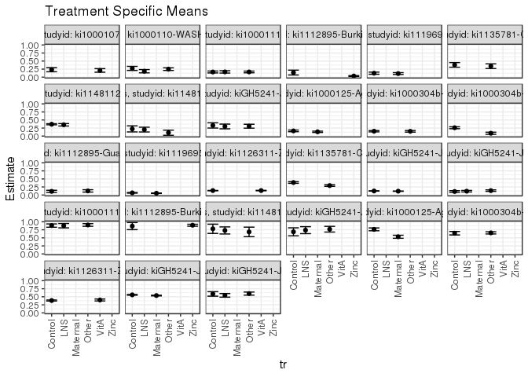

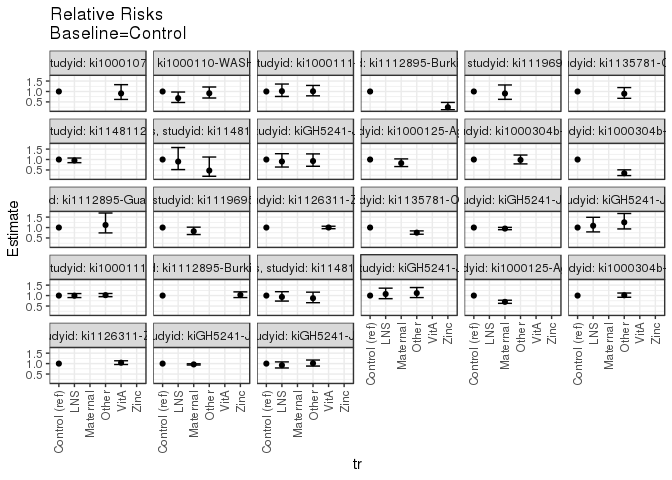

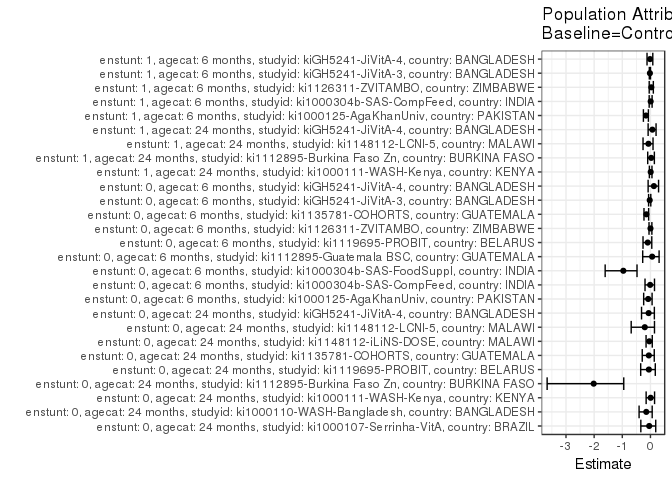

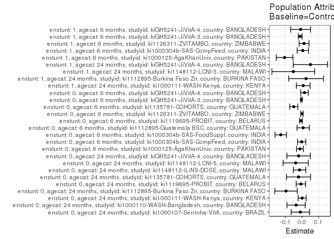

## Results Table

### Parameter: TSM

| enstunt | agecat | studyid | country | intervention_level | baseline_level | estimate | ci_lower | ci_upper |
| --- | --- | --- | --- | --- | --- | --- | --- | --- |
| 0 | 6 months | ki1000125-AgaKhanUniv | PAKISTAN | Control | NA | 0.1615385 | 0.1359478 | 0.1871291 |
| 0 | 6 months | ki1000125-AgaKhanUniv | PAKISTAN | Maternal | NA | 0.1333333 | 0.1128629 | 0.1538038 |
| 0 | 6 months | ki1000304b-SAS-CompFeed | INDIA | Control | NA | 0.1513761 | 0.1307636 | 0.1719887 |
| 0 | 6 months | ki1000304b-SAS-CompFeed | INDIA | Other | NA | 0.1483051 | 0.1235616 | 0.1730485 |
| 0 | 6 months | ki1000304b-SAS-FoodSuppl | INDIA | Control | NA | 0.2592593 | 0.2294167 | 0.2891018 |
| 0 | 6 months | ki1000304b-SAS-FoodSuppl | INDIA | Other | NA | 0.0886076 | 0.0555055 | 0.1217097 |
| 0 | 6 months | ki1112895-Guatemala BSC | GUATEMALA | Control | NA | 0.1139241 | 0.0802775 | 0.1475706 |
| 0 | 6 months | ki1112895-Guatemala BSC | GUATEMALA | Other | NA | 0.1279070 | 0.0910040 | 0.1648100 |
| 0 | 6 months | ki1119695-PROBIT | BELARUS | Control | NA | 0.0674643 | 0.0567796 | 0.0781490 |
| 0 | 6 months | ki1119695-PROBIT | BELARUS | Maternal | NA | 0.0555647 | 0.0475024 | 0.0636270 |
| 0 | 6 months | ki1126311-ZVITAMBO | ZIMBABWE | Control | NA | 0.1385965 | 0.1345347 | 0.1426583 |
| 0 | 6 months | ki1126311-ZVITAMBO | ZIMBABWE | VitA | NA | 0.1388621 | 0.1317835 | 0.1459407 |
| 0 | 6 months | ki1135781-COHORTS | GUATEMALA | Control | NA | 0.3888889 | 0.3637360 | 0.4140418 |
| 0 | 6 months | ki1135781-COHORTS | GUATEMALA | Other | NA | 0.2936288 | 0.2694869 | 0.3177707 |
| 0 | 6 months | kiGH5241-JiVitA-3 | BANGLADESH | Control | NA | 0.1256675 | 0.1202835 | 0.1310515 |
| 0 | 6 months | kiGH5241-JiVitA-3 | BANGLADESH | Maternal | NA | 0.1194459 | 0.1148153 | 0.1240764 |
| 0 | 6 months | kiGH5241-JiVitA-4 | BANGLADESH | Control | NA | 0.1094470 | 0.0831336 | 0.1357604 |
| 0 | 6 months | kiGH5241-JiVitA-4 | BANGLADESH | LNS | NA | 0.1189128 | 0.0944011 | 0.1434245 |
| 0 | 6 months | kiGH5241-JiVitA-4 | BANGLADESH | Other | NA | 0.1368143 | 0.1141976 | 0.1594309 |
| 0 | 24 months | ki1000107-Serrinha-VitA | BRAZIL | Control | NA | 0.2307692 | 0.1677546 | 0.2937838 |
| 0 | 24 months | ki1000107-Serrinha-VitA | BRAZIL | VitA | NA | 0.2093023 | 0.1539738 | 0.2646308 |
| 0 | 24 months | ki1000110-WASH-Bangladesh | BANGLADESH | Control | NA | 0.2722513 | 0.2090880 | 0.3354146 |
| 0 | 24 months | ki1000110-WASH-Bangladesh | BANGLADESH | LNS | NA | 0.1846847 | 0.1336098 | 0.2357596 |
| 0 | 24 months | ki1000110-WASH-Bangladesh | BANGLADESH | Other | NA | 0.2488372 | 0.2079492 | 0.2897252 |
| 0 | 24 months | ki1000111-WASH-Kenya | KENYA | Control | NA | 0.1607445 | 0.1311240 | 0.1903650 |
| 0 | 24 months | ki1000111-WASH-Kenya | KENYA | LNS | NA | 0.1633166 | 0.1269899 | 0.1996433 |
| 0 | 24 months | ki1000111-WASH-Kenya | KENYA | Other | NA | 0.1623377 | 0.1362839 | 0.1883914 |
| 0 | 24 months | ki1112895-Burkina Faso Zn | BURKINA FASO | Control | NA | 0.1428571 | 0.0679747 | 0.2177396 |
| 0 | 24 months | ki1112895-Burkina Faso Zn | BURKINA FASO | Zinc | NA | 0.0351145 | 0.0210085 | 0.0492205 |
| 0 | 24 months | ki1119695-PROBIT | BELARUS | Control | NA | 0.1233244 | 0.0902369 | 0.1564119 |
| 0 | 24 months | ki1119695-PROBIT | BELARUS | Maternal | NA | 0.1115880 | 0.0829935 | 0.1401825 |
| 0 | 24 months | ki1135781-COHORTS | GUATEMALA | Control | NA | 0.3809524 | 0.3088065 | 0.4530982 |
| 0 | 24 months | ki1135781-COHORTS | GUATEMALA | Other | NA | 0.3409091 | 0.2688303 | 0.4129879 |
| 0 | 24 months | ki1148112-iLiNS-DOSE | MALAWI | Control | NA | 0.3678161 | 0.3509444 | 0.3846878 |
| 0 | 24 months | ki1148112-iLiNS-DOSE | MALAWI | LNS | NA | 0.3509174 | 0.3135358 | 0.3882990 |
| 0 | 24 months | ki1148112-LCNI-5 | MALAWI | Control | NA | 0.2236842 | 0.1298072 | 0.3175612 |
| 0 | 24 months | ki1148112-LCNI-5 | MALAWI | LNS | NA | 0.2017544 | 0.1279374 | 0.2755714 |
| 0 | 24 months | ki1148112-LCNI-5 | MALAWI | Other | NA | 0.1052632 | 0.0254311 | 0.1850952 |
| 0 | 24 months | kiGH5241-JiVitA-4 | BANGLADESH | Control | NA | 0.3312883 | 0.2498046 | 0.4127721 |
| 0 | 24 months | kiGH5241-JiVitA-4 | BANGLADESH | LNS | NA | 0.2994350 | 0.2263338 | 0.3725362 |
| 0 | 24 months | kiGH5241-JiVitA-4 | BANGLADESH | Other | NA | 0.3071895 | 0.2468465 | 0.3675326 |
| 1 | 6 months | ki1000125-AgaKhanUniv | PAKISTAN | Control | NA | 0.7641509 | 0.7198790 | 0.8084228 |
| 1 | 6 months | ki1000125-AgaKhanUniv | PAKISTAN | Maternal | NA | 0.5340909 | 0.4866920 | 0.5814898 |
| 1 | 6 months | ki1000304b-SAS-CompFeed | INDIA | Control | NA | 0.6447368 | 0.5905587 | 0.6989150 |
| 1 | 6 months | ki1000304b-SAS-CompFeed | INDIA | Other | NA | 0.6547619 | 0.6204851 | 0.6890387 |
| 1 | 6 months | ki1126311-ZVITAMBO | ZIMBABWE | Control | NA | 0.3837838 | 0.3673004 | 0.4002671 |
| 1 | 6 months | ki1126311-ZVITAMBO | ZIMBABWE | VitA | NA | 0.4003322 | 0.3703742 | 0.4302903 |
| 1 | 6 months | kiGH5241-JiVitA-3 | BANGLADESH | Control | NA | 0.5599685 | 0.5480087 | 0.5719284 |
| 1 | 6 months | kiGH5241-JiVitA-3 | BANGLADESH | Maternal | NA | 0.5383977 | 0.5270103 | 0.5497850 |
| 1 | 6 months | kiGH5241-JiVitA-4 | BANGLADESH | Control | NA | 0.5891720 | 0.5196956 | 0.6586484 |
| 1 | 6 months | kiGH5241-JiVitA-4 | BANGLADESH | LNS | NA | 0.5447154 | 0.4886345 | 0.6007964 |
| 1 | 6 months | kiGH5241-JiVitA-4 | BANGLADESH | Other | NA | 0.5990180 | 0.5513883 | 0.6466477 |
| 1 | 24 months | ki1000111-WASH-Kenya | KENYA | Control | NA | 0.8815789 | 0.8301566 | 0.9330013 |
| 1 | 24 months | ki1000111-WASH-Kenya | KENYA | LNS | NA | 0.8777778 | 0.8100331 | 0.9455225 |
| 1 | 24 months | ki1000111-WASH-Kenya | KENYA | Other | NA | 0.9000000 | 0.8593799 | 0.9406201 |
| 1 | 24 months | ki1112895-Burkina Faso Zn | BURKINA FASO | Control | NA | 0.8648649 | 0.7545803 | 0.9751494 |
| 1 | 24 months | ki1112895-Burkina Faso Zn | BURKINA FASO | Zinc | NA | 0.8923077 | 0.8615060 | 0.9231094 |
| 1 | 24 months | ki1148112-LCNI-5 | MALAWI | Control | NA | 0.7812500 | 0.6374758 | 0.9250242 |
| 1 | 24 months | ki1148112-LCNI-5 | MALAWI | LNS | NA | 0.7301587 | 0.6201367 | 0.8401807 |
| 1 | 24 months | ki1148112-LCNI-5 | MALAWI | Other | NA | 0.6842105 | 0.5358601 | 0.8325610 |
| 1 | 24 months | kiGH5241-JiVitA-4 | BANGLADESH | Control | NA | 0.6875000 | 0.5636937 | 0.8113063 |
| 1 | 24 months | kiGH5241-JiVitA-4 | BANGLADESH | LNS | NA | 0.7391304 | 0.6309167 | 0.8473441 |
| 1 | 24 months | kiGH5241-JiVitA-4 | BANGLADESH | Other | NA | 0.7692308 | 0.6808963 | 0.8575652 |

### Parameter: E(Y)

| enstunt | agecat | studyid | country | intervention_level | baseline_level | estimate | ci_lower | ci_upper |
| --- | --- | --- | --- | --- | --- | --- | --- | --- |
| 0 | 6 months | ki1000125-AgaKhanUniv | PAKISTAN | NA | NA | 0.1494505 | 0.1166547 | 0.1822464 |
| 0 | 6 months | ki1000304b-SAS-CompFeed | INDIA | NA | NA | 0.1497797 | 0.1173613 | 0.1821981 |
| 0 | 6 months | ki1000304b-SAS-FoodSuppl | INDIA | NA | NA | 0.1320755 | 0.0863920 | 0.1777589 |
| 0 | 6 months | ki1112895-Guatemala BSC | GUATEMALA | NA | NA | 0.1212121 | 0.0712615 | 0.1711628 |
| 0 | 6 months | ki1119695-PROBIT | BELARUS | NA | NA | 0.0614825 | 0.0474925 | 0.0754726 |
| 0 | 6 months | ki1126311-ZVITAMBO | ZIMBABWE | NA | NA | 0.1387962 | 0.1306350 | 0.1469574 |
| 0 | 6 months | ki1135781-COHORTS | GUATEMALA | NA | NA | 0.3399716 | 0.3049301 | 0.3750130 |
| 0 | 6 months | kiGH5241-JiVitA-3 | BANGLADESH | NA | NA | 0.1224755 | 0.1153631 | 0.1295880 |
| 0 | 6 months | kiGH5241-JiVitA-4 | BANGLADESH | NA | NA | 0.1246936 | 0.1104156 | 0.1389717 |
| 0 | 24 months | ki1000107-Serrinha-VitA | BRAZIL | NA | NA | 0.2210526 | 0.1371673 | 0.3049380 |
| 0 | 24 months | ki1000110-WASH-Bangladesh | BANGLADESH | NA | NA | 0.2372479 | 0.2085147 | 0.2659812 |
| 0 | 24 months | ki1000111-WASH-Kenya | KENYA | NA | NA | 0.1620239 | 0.1447995 | 0.1792483 |
| 0 | 24 months | ki1112895-Burkina Faso Zn | BURKINA FASO | NA | NA | 0.0473613 | 0.0320365 | 0.0626861 |
| 0 | 24 months | ki1119695-PROBIT | BELARUS | NA | NA | 0.1168057 | 0.0733203 | 0.1602912 |
| 0 | 24 months | ki1135781-COHORTS | GUATEMALA | NA | NA | 0.3604651 | 0.2583941 | 0.4625361 |
| 0 | 24 months | ki1148112-iLiNS-DOSE | MALAWI | NA | NA | 0.3537285 | 0.3127123 | 0.3947447 |
| 0 | 24 months | ki1148112-LCNI-5 | MALAWI | NA | NA | 0.1862348 | 0.1375873 | 0.2348823 |
| 0 | 24 months | kiGH5241-JiVitA-4 | BANGLADESH | NA | NA | 0.3111455 | 0.2706141 | 0.3516769 |
| 1 | 6 months | ki1000125-AgaKhanUniv | PAKISTAN | NA | NA | 0.6597938 | 0.5929525 | 0.7266351 |
| 1 | 6 months | ki1000304b-SAS-CompFeed | INDIA | NA | NA | 0.6500000 | 0.5861714 | 0.7138286 |
| 1 | 6 months | ki1126311-ZVITAMBO | ZIMBABWE | NA | NA | 0.3964422 | 0.3622453 | 0.4306390 |
| 1 | 6 months | kiGH5241-JiVitA-3 | BANGLADESH | NA | NA | 0.5494750 | 0.5329435 | 0.5660064 |
| 1 | 6 months | kiGH5241-JiVitA-4 | BANGLADESH | NA | NA | 0.5811437 | 0.5486800 | 0.6136075 |
| 1 | 24 months | ki1000111-WASH-Kenya | KENYA | NA | NA | 0.8893805 | 0.8604325 | 0.9183286 |
| 1 | 24 months | ki1112895-Burkina Faso Zn | BURKINA FASO | NA | NA | 0.8899297 | 0.8602092 | 0.9196502 |
| 1 | 24 months | ki1148112-LCNI-5 | MALAWI | NA | NA | 0.7293233 | 0.6535273 | 0.8051194 |
| 1 | 24 months | kiGH5241-JiVitA-4 | BANGLADESH | NA | NA | 0.7383966 | 0.6779662 | 0.7988271 |

### Parameter: RR

| enstunt | agecat | studyid | country | intervention_level | baseline_level | estimate | ci_lower | ci_upper |
| --- | --- | --- | --- | --- | --- | --- | --- | --- |
| 0 | 6 months | ki1000125-AgaKhanUniv | PAKISTAN | Control | Control | 1.0000000 | 1.0000000 | 1.0000000 |
| 0 | 6 months | ki1000125-AgaKhanUniv | PAKISTAN | Maternal | Control | 0.8253968 | 0.6619948 | 1.0291318 |
| 0 | 6 months | ki1000304b-SAS-CompFeed | INDIA | Control | Control | 1.0000000 | 1.0000000 | 1.0000000 |
| 0 | 6 months | ki1000304b-SAS-CompFeed | INDIA | Other | Control | 0.9797124 | 0.7903093 | 1.2145072 |
| 0 | 6 months | ki1000304b-SAS-FoodSuppl | INDIA | Control | Control | 1.0000000 | 1.0000000 | 1.0000000 |
| 0 | 6 months | ki1000304b-SAS-FoodSuppl | INDIA | Other | Control | 0.3417722 | 0.2311882 | 0.5052516 |
| 0 | 6 months | ki1112895-Guatemala BSC | GUATEMALA | Control | Control | 1.0000000 | 1.0000000 | 1.0000000 |
| 0 | 6 months | ki1112895-Guatemala BSC | GUATEMALA | Other | Control | 1.1227390 | 0.7429652 | 1.6966378 |
| 0 | 6 months | ki1119695-PROBIT | BELARUS | Control | Control | 1.0000000 | 1.0000000 | 1.0000000 |
| 0 | 6 months | ki1119695-PROBIT | BELARUS | Maternal | Control | 0.8236165 | 0.6654524 | 1.0193728 |
| 0 | 6 months | ki1126311-ZVITAMBO | ZIMBABWE | Control | Control | 1.0000000 | 1.0000000 | 1.0000000 |
| 0 | 6 months | ki1126311-ZVITAMBO | ZIMBABWE | VitA | Control | 1.0019164 | 0.9447024 | 1.0625955 |
| 0 | 6 months | ki1135781-COHORTS | GUATEMALA | Control | Control | 1.0000000 | 1.0000000 | 1.0000000 |
| 0 | 6 months | ki1135781-COHORTS | GUATEMALA | Other | Control | 0.7550455 | 0.6800509 | 0.8383104 |
| 0 | 6 months | kiGH5241-JiVitA-3 | BANGLADESH | Control | Control | 1.0000000 | 1.0000000 | 1.0000000 |
| 0 | 6 months | kiGH5241-JiVitA-3 | BANGLADESH | Maternal | Control | 0.9504912 | 0.8971343 | 1.0070215 |
| 0 | 6 months | kiGH5241-JiVitA-4 | BANGLADESH | Control | Control | 1.0000000 | 1.0000000 | 1.0000000 |
| 0 | 6 months | kiGH5241-JiVitA-4 | BANGLADESH | LNS | Control | 1.0864875 | 0.7915372 | 1.4913449 |
| 0 | 6 months | kiGH5241-JiVitA-4 | BANGLADESH | Other | Control | 1.2500504 | 0.9336777 | 1.6736248 |
| 0 | 24 months | ki1000107-Serrinha-VitA | BRAZIL | Control | Control | 1.0000000 | 1.0000000 | 1.0000000 |
| 0 | 24 months | ki1000107-Serrinha-VitA | BRAZIL | VitA | Control | 0.9069767 | 0.6202113 | 1.3263333 |
| 0 | 24 months | ki1000110-WASH-Bangladesh | BANGLADESH | Control | Control | 1.0000000 | 1.0000000 | 1.0000000 |
| 0 | 24 months | ki1000110-WASH-Bangladesh | BANGLADESH | LNS | Control | 0.6783611 | 0.4728128 | 0.9732684 |
| 0 | 24 months | ki1000110-WASH-Bangladesh | BANGLADESH | Other | Control | 0.9139982 | 0.6878221 | 1.2145477 |
| 0 | 24 months | ki1000111-WASH-Kenya | KENYA | Control | Control | 1.0000000 | 1.0000000 | 1.0000000 |
| 0 | 24 months | ki1000111-WASH-Kenya | KENYA | LNS | Control | 1.0160011 | 0.7611152 | 1.3562442 |
| 0 | 24 months | ki1000111-WASH-Kenya | KENYA | Other | Control | 1.0099111 | 0.7909659 | 1.2894621 |
| 0 | 24 months | ki1112895-Burkina Faso Zn | BURKINA FASO | Control | Control | 1.0000000 | 1.0000000 | 1.0000000 |
| 0 | 24 months | ki1112895-Burkina Faso Zn | BURKINA FASO | Zinc | Control | 0.2458015 | 0.1269914 | 0.4757677 |
| 0 | 24 months | ki1119695-PROBIT | BELARUS | Control | Control | 1.0000000 | 1.0000000 | 1.0000000 |
| 0 | 24 months | ki1119695-PROBIT | BELARUS | Maternal | Control | 0.9048330 | 0.6234475 | 1.3132185 |
| 0 | 24 months | ki1135781-COHORTS | GUATEMALA | Control | Control | 1.0000000 | 1.0000000 | 1.0000000 |
| 0 | 24 months | ki1135781-COHORTS | GUATEMALA | Other | Control | 0.8948864 | 0.6737438 | 1.1886145 |
| 0 | 24 months | ki1148112-iLiNS-DOSE | MALAWI | Control | Control | 1.0000000 | 1.0000000 | 1.0000000 |
| 0 | 24 months | ki1148112-iLiNS-DOSE | MALAWI | LNS | Control | 0.9540568 | 0.8495797 | 1.0713819 |
| 0 | 24 months | ki1148112-LCNI-5 | MALAWI | Control | Control | 1.0000000 | 1.0000000 | 1.0000000 |
| 0 | 24 months | ki1148112-LCNI-5 | MALAWI | LNS | Control | 0.9019608 | 0.5168714 | 1.5739569 |
| 0 | 24 months | ki1148112-LCNI-5 | MALAWI | Other | Control | 0.4705882 | 0.1977888 | 1.1196450 |
| 0 | 24 months | kiGH5241-JiVitA-4 | BANGLADESH | Control | Control | 1.0000000 | 1.0000000 | 1.0000000 |
| 0 | 24 months | kiGH5241-JiVitA-4 | BANGLADESH | LNS | Control | 0.9038502 | 0.6390033 | 1.2784677 |
| 0 | 24 months | kiGH5241-JiVitA-4 | BANGLADESH | Other | Control | 0.9272573 | 0.6769652 | 1.2700891 |
| 1 | 6 months | ki1000125-AgaKhanUniv | PAKISTAN | Control | Control | 1.0000000 | 1.0000000 | 1.0000000 |
| 1 | 6 months | ki1000125-AgaKhanUniv | PAKISTAN | Maternal | Control | 0.6989338 | 0.6286484 | 0.7770774 |
| 1 | 6 months | ki1000304b-SAS-CompFeed | INDIA | Control | Control | 1.0000000 | 1.0000000 | 1.0000000 |
| 1 | 6 months | ki1000304b-SAS-CompFeed | INDIA | Other | Control | 1.0155491 | 0.9188047 | 1.1224800 |
| 1 | 6 months | ki1126311-ZVITAMBO | ZIMBABWE | Control | Control | 1.0000000 | 1.0000000 | 1.0000000 |
| 1 | 6 months | ki1126311-ZVITAMBO | ZIMBABWE | VitA | Control | 1.0431192 | 0.9568900 | 1.1371188 |
| 1 | 6 months | kiGH5241-JiVitA-3 | BANGLADESH | Control | Control | 1.0000000 | 1.0000000 | 1.0000000 |
| 1 | 6 months | kiGH5241-JiVitA-3 | BANGLADESH | Maternal | Control | 0.9614784 | 0.9329988 | 0.9908274 |
| 1 | 6 months | kiGH5241-JiVitA-4 | BANGLADESH | Control | Control | 1.0000000 | 1.0000000 | 1.0000000 |
| 1 | 6 months | kiGH5241-JiVitA-4 | BANGLADESH | LNS | Control | 0.9245441 | 0.7905598 | 1.0812359 |
| 1 | 6 months | kiGH5241-JiVitA-4 | BANGLADESH | Other | Control | 1.0167116 | 0.8819188 | 1.1721063 |
| 1 | 24 months | ki1000111-WASH-Kenya | KENYA | Control | Control | 1.0000000 | 1.0000000 | 1.0000000 |
| 1 | 24 months | ki1000111-WASH-Kenya | KENYA | LNS | Control | 0.9956882 | 0.9038773 | 1.0968248 |
| 1 | 24 months | ki1000111-WASH-Kenya | KENYA | Other | Control | 1.0208955 | 0.9483117 | 1.0990350 |
| 1 | 24 months | ki1112895-Burkina Faso Zn | BURKINA FASO | Control | Control | 1.0000000 | 1.0000000 | 1.0000000 |
| 1 | 24 months | ki1112895-Burkina Faso Zn | BURKINA FASO | Zinc | Control | 1.0317308 | 0.9040520 | 1.1774415 |
| 1 | 24 months | ki1148112-LCNI-5 | MALAWI | Control | Control | 1.0000000 | 1.0000000 | 1.0000000 |
| 1 | 24 months | ki1148112-LCNI-5 | MALAWI | LNS | Control | 0.9346032 | 0.7367673 | 1.1855616 |
| 1 | 24 months | ki1148112-LCNI-5 | MALAWI | Other | Control | 0.8757895 | 0.6590074 | 1.1638826 |
| 1 | 24 months | kiGH5241-JiVitA-4 | BANGLADESH | Control | Control | 1.0000000 | 1.0000000 | 1.0000000 |
| 1 | 24 months | kiGH5241-JiVitA-4 | BANGLADESH | LNS | Control | 1.0750988 | 0.8524292 | 1.3559337 |
| 1 | 24 months | kiGH5241-JiVitA-4 | BANGLADESH | Other | Control | 1.1188811 | 0.9037226 | 1.3852646 |

### Parameter: PAR

| enstunt | agecat | studyid | country | intervention_level | baseline_level | estimate | ci_lower | ci_upper |
| --- | --- | --- | --- | --- | --- | --- | --- | --- |
| 0 | 6 months | ki1000125-AgaKhanUniv | PAKISTAN | Control | NA | -0.0120879 | -0.0325986 | 0.0084228 |
| 0 | 6 months | ki1000304b-SAS-CompFeed | INDIA | Control | NA | -0.0015964 | -0.0264204 | 0.0232276 |
| 0 | 6 months | ki1000304b-SAS-FoodSuppl | INDIA | Control | NA | -0.1271838 | -0.1617728 | -0.0925948 |
| 0 | 6 months | ki1112895-Guatemala BSC | GUATEMALA | Control | NA | 0.0072881 | -0.0296304 | 0.0442066 |
| 0 | 6 months | ki1119695-PROBIT | BELARUS | Control | NA | -0.0059818 | -0.0145794 | 0.0026159 |
| 0 | 6 months | ki1126311-ZVITAMBO | ZIMBABWE | Control | NA | 0.0001997 | -0.0068789 | 0.0072783 |
| 0 | 6 months | ki1135781-COHORTS | GUATEMALA | Control | NA | -0.0489173 | -0.0733148 | -0.0245199 |
| 0 | 6 months | kiGH5241-JiVitA-3 | BANGLADESH | Control | NA | -0.0031920 | -0.0078312 | 0.0014473 |
| 0 | 6 months | kiGH5241-JiVitA-4 | BANGLADESH | Control | NA | 0.0152466 | -0.0077504 | 0.0382437 |
| 0 | 24 months | ki1000107-Serrinha-VitA | BRAZIL | Control | NA | -0.0097166 | -0.0650872 | 0.0456540 |
| 0 | 24 months | ki1000110-WASH-Bangladesh | BANGLADESH | Control | NA | -0.0350034 | -0.0898426 | 0.0198358 |
| 0 | 24 months | ki1000111-WASH-Kenya | KENYA | Control | NA | 0.0012794 | -0.0228967 | 0.0254555 |
| 0 | 24 months | ki1112895-Burkina Faso Zn | BURKINA FASO | Control | NA | -0.0954958 | -0.1630790 | -0.0279127 |
| 0 | 24 months | ki1119695-PROBIT | BELARUS | Control | NA | -0.0065187 | -0.0348704 | 0.0218330 |
| 0 | 24 months | ki1135781-COHORTS | GUATEMALA | Control | NA | -0.0204873 | -0.0926916 | 0.0517171 |
| 0 | 24 months | ki1148112-iLiNS-DOSE | MALAWI | Control | NA | -0.0140876 | -0.0514731 | 0.0232979 |
| 0 | 24 months | ki1148112-LCNI-5 | MALAWI | Control | NA | -0.0374494 | -0.1133187 | 0.0384199 |
| 0 | 24 months | kiGH5241-JiVitA-4 | BANGLADESH | Control | NA | -0.0201428 | -0.0904331 | 0.0501474 |
| 1 | 6 months | ki1000125-AgaKhanUniv | PAKISTAN | Control | NA | -0.1043571 | -0.1544346 | -0.0542797 |
| 1 | 6 months | ki1000304b-SAS-CompFeed | INDIA | Control | NA | 0.0052632 | -0.0287253 | 0.0392516 |
| 1 | 6 months | ki1126311-ZVITAMBO | ZIMBABWE | Control | NA | 0.0126584 | -0.0173036 | 0.0426205 |
| 1 | 6 months | kiGH5241-JiVitA-3 | BANGLADESH | Control | NA | -0.0104936 | -0.0219367 | 0.0009495 |
| 1 | 6 months | kiGH5241-JiVitA-4 | BANGLADESH | Control | NA | -0.0080282 | -0.0675203 | 0.0514639 |
| 1 | 24 months | ki1000111-WASH-Kenya | KENYA | Control | NA | 0.0078016 | -0.0334757 | 0.0490788 |
| 1 | 24 months | ki1112895-Burkina Faso Zn | BURKINA FASO | Control | NA | 0.0250649 | -0.0795208 | 0.1296506 |
| 1 | 24 months | ki1148112-LCNI-5 | MALAWI | Control | NA | -0.0519267 | -0.1802587 | 0.0764053 |
| 1 | 24 months | kiGH5241-JiVitA-4 | BANGLADESH | Control | NA | 0.0508966 | -0.0523229 | 0.1541162 |

### Parameter: PAF

| enstunt | agecat | studyid | country | intervention_level | baseline_level | estimate | ci_lower | ci_upper |
| --- | --- | --- | --- | --- | --- | --- | --- | --- |
| 0 | 6 months | ki1000125-AgaKhanUniv | PAKISTAN | Control | NA | -0.0808824 | -0.2406247 | 0.0582916 |
| 0 | 6 months | ki1000304b-SAS-CompFeed | INDIA | Control | NA | -0.0106584 | -0.1928665 | 0.1437177 |
| 0 | 6 months | ki1000304b-SAS-FoodSuppl | INDIA | Control | NA | -0.9629630 | -1.6086548 | -0.4770922 |
| 0 | 6 months | ki1112895-Guatemala BSC | GUATEMALA | Control | NA | 0.0601266 | -0.2751768 | 0.3072631 |
| 0 | 6 months | ki1119695-PROBIT | BELARUS | Control | NA | -0.0972919 | -0.2638548 | 0.0473197 |
| 0 | 6 months | ki1126311-ZVITAMBO | ZIMBABWE | Control | NA | 0.0014391 | -0.0508086 | 0.0510889 |
| 0 | 6 months | ki1135781-COHORTS | GUATEMALA | Control | NA | -0.1438866 | -0.2297316 | -0.0640342 |
| 0 | 6 months | kiGH5241-JiVitA-3 | BANGLADESH | Control | NA | -0.0260622 | -0.0656932 | 0.0120950 |
| 0 | 6 months | kiGH5241-JiVitA-4 | BANGLADESH | Control | NA | 0.1222727 | -0.0825578 | 0.2883472 |
| 0 | 24 months | ki1000107-Serrinha-VitA | BRAZIL | Control | NA | -0.0439560 | -0.3415035 | 0.1875950 |
| 0 | 24 months | ki1000110-WASH-Bangladesh | BANGLADESH | Control | NA | -0.1475393 | -0.4033697 | 0.0616540 |
| 0 | 24 months | ki1000111-WASH-Kenya | KENYA | Control | NA | 0.0078962 | -0.1531204 | 0.1464292 |
| 0 | 24 months | ki1112895-Burkina Faso Zn | BURKINA FASO | Control | NA | -2.0163265 | -3.6698921 | -0.9482732 |
| 0 | 24 months | ki1119695-PROBIT | BELARUS | Control | NA | -0.0558078 | -0.3463970 | 0.1720642 |
| 0 | 24 months | ki1135781-COHORTS | GUATEMALA | Control | NA | -0.0568356 | -0.2915938 | 0.1352532 |
| 0 | 24 months | ki1148112-iLiNS-DOSE | MALAWI | Control | NA | -0.0398260 | -0.1557610 | 0.0644794 |
| 0 | 24 months | ki1148112-LCNI-5 | MALAWI | Control | NA | -0.2010870 | -0.6839387 | 0.1433121 |
| 0 | 24 months | kiGH5241-JiVitA-4 | BANGLADESH | Control | NA | -0.0647377 | -0.3164921 | 0.1388735 |
| 1 | 6 months | ki1000125-AgaKhanUniv | PAKISTAN | Control | NA | -0.1581663 | -0.2501803 | -0.0729245 |
| 1 | 6 months | ki1000304b-SAS-CompFeed | INDIA | Control | NA | 0.0080972 | -0.0451571 | 0.0586380 |
| 1 | 6 months | ki1126311-ZVITAMBO | ZIMBABWE | Control | NA | 0.0319300 | -0.0440829 | 0.1024089 |
| 1 | 6 months | kiGH5241-JiVitA-3 | BANGLADESH | Control | NA | -0.0190975 | -0.0405463 | 0.0019093 |
| 1 | 6 months | kiGH5241-JiVitA-4 | BANGLADESH | Control | NA | -0.0138145 | -0.1214838 | 0.0835178 |
| 1 | 24 months | ki1000111-WASH-Kenya | KENYA | Control | NA | 0.0087719 | -0.0387567 | 0.0541259 |
| 1 | 24 months | ki1112895-Burkina Faso Zn | BURKINA FASO | Control | NA | 0.0281650 | -0.0968199 | 0.1389076 |
| 1 | 24 months | ki1148112-LCNI-5 | MALAWI | Control | NA | -0.0711985 | -0.2633094 | 0.0916982 |
| 1 | 24 months | kiGH5241-JiVitA-4 | BANGLADESH | Control | NA | 0.0689286 | -0.0825675 | 0.1992240 |